# Accessing WoSIS from R – ‘Latest’ Version

D G Rossiter

04-July-2022

# 1 Introduction

This document shows how to access WoSIS “Latest” data from R. For access to WoSIS “Snapshot” data from R, see `WoSIS_Snapshot_with_R.Rmd` at https://git.wur.nl/Batje001/wosis/-/tree/master/R_scripts.

The “Latest” dynamic dataset contains the most recent version of standardised soil data served from WoSIS. Being dynamic, the dataset will grow once new point data are standardised, additional soil properties are considered, and/or when possible amendments are required.

For an overview of WoSIS, see https://www.isric.org/explore/wosis. This links to https://www.isric.org/explore/wosis/accessing-wosis-derived-datasets which explains the difference between snapshot and dynamic datasets, and how to access them.

The [Procedures Manual](https://dx.doi.org/10.17027/isric-wdc-2020-01) describes how the WoSIS database is built.

# 2 Packages

If you do not have these on your system, install with `install.packages(..., dependencies=TRUE)` or via the R Studio package manager.

The `gdalUtilities` package replaces the obsolete `gdalUtils` package, and as of end June 2022 must be installed from its author’s github repository, using the `instll_github` function of the `devtools` package.

However, some functions (notably, `ogrinfo`) are not implemented there, and so `gdalUtils` must be used for these, and therefore your system must have a GDAL installation.

In a future version of these procedures we will find a way to replace `ogrinfo` with currently-supported packages.

```r
# library(devtools)
# devtools::install_github("JoshOBrien/gdalUtilities")
library(gdalUtilities)      # wrappers for GDAL utility programs that could be
                        #  called from the command line, but here via `sf`
# devtools::install_github("gearslaboratory/gdalUtils")
library(gdalUtils)      # wrappers for GDAL utility programs that could be
                        #  called from the command line,
library(sf)             # spatial data types -- Simple Features
library(stars)          # Spatiotemporal Arrays, Raster and Vector Data Cubes
library(dplyr)          # tidyverse data manipulation functions
```

```r
library(ggplot2)        # gpplot graphics
library(maps)           # optional -- for boundary polygons
library(mapdata)
```

The `stars` and `sf` packages have built-in support for GDAL, the Geographic Data Abstraction Library. This is used to read, write and convert between formats. The `gdalUtilities` package provides direct access to GDAL via `sf::gdal_utils`.

Check the drivers supported by your installation, and their capabilities, for the three we will use: the [OGC GeoPackages](https://www.geopackage.org) `GPKG`, the ESRI shapefile `ESRI`, and the CSV flat text file format `CSV`:

```r
drivers <- sf::st_drivers()
# print(drivers)
ix <- grep("GPKG", drivers$name,  fixed=TRUE)
drivers[ix,]
```

```
##      name  long_name write copy is_raster is_vector  vsi
## GPKG GPKG GeoPackage  TRUE TRUE      TRUE      TRUE TRUE
```

```r
ix <- grep("ESRI", drivers$name,  fixed=TRUE)
drivers[ix,]
```

```
##                          name          long_name write  copy is_raster
## ESRIC                   ESRIC Esri Compact Cache FALSE FALSE      TRUE
## ESRI Shapefile ESRI Shapefile     ESRI Shapefile  TRUE FALSE     FALSE
## ESRIJSON             ESRIJSON           ESRIJSON FALSE FALSE     FALSE
##                is_vector  vsi
## ESRIC               TRUE TRUE
## ESRI Shapefile      TRUE TRUE
## ESRIJSON            TRUE TRUE
```

```r
ix <- grep("CSV", drivers$name,  fixed=TRUE)
drivers[ix,]
```

```
##     name                    long_name write  copy is_raster is_vector  vsi
## CSV  CSV Comma Separated Value (.csv)  TRUE FALSE     FALSE      TRUE TRUE
```

# 3 WoSIS Web Feature Service

The “latest” (dynamic) version of WoSIS is provided via [WFS (Web Feature Services)](https://www.opengeospatial.org/standards/wfs). This is described in less technical terms in [Wikipedia](https://en.wikipedia.org/wiki/Web_Feature_Service).

WFS allows you to incorporate geographic data into your own GIS projects, unlike WMS (Web Map Service), which only displays geographic data within a GIS. Here we use R as the GIS, since it can handle both geographic and feature-space information.

## 3.1 Specify WoSIS WFS and list available layers

Specify the web address of the “latest” version of WoSIS:

```r
wfs <- "WFS:https://maps.isric.org/mapserv?map=/map/wosis_latest.map"
```

List the layers in the WFS source with the `sf::st_layers` function.

```r
(layers.info <- st_layers(wfs))
```

```
## Driver: WFS
## Available layers:
##                  layer_name geometry_type features fields
## 1    ms:wosis_latest_bdfi33                  78058     15
## 2    ms:wosis_latest_bdfiad                  21033     15
## 3    ms:wosis_latest_bdfifm                  14160     15
## 4    ms:wosis_latest_bdfiod                 122699     15
## 5    ms:wosis_latest_bdws33                 154203     15
## 6    ms:wosis_latest_bdwsod                  75306     15
## 7    ms:wosis_latest_cecph7                 294224     15
## 8    ms:wosis_latest_cecph8                  24118     15
## 9      ms:wosis_latest_cfgr                 202376     15
## 10     ms:wosis_latest_cfvo                 234848     15
## 11     ms:wosis_latest_clay                 630284     15
## 12     ms:wosis_latest_ecec                 132734     15
```

[output cut: 33 more lines]

## 3.2 Display site properties

The layer `"ms:wosis_latest:wosis_latest_profiles"` contains the site information.

The `gdalUtils::ogrinfo` function displays information about a dataset accessible via GDAL. Here we see the metadata for the site information. Note the `so` “summary only” option. This suppresses listing of features, and shows only the summary information. We choose this because there are many profiles in the entire dataset.

The options for `ogrinfo` are listed [at the GDAL on-line reference page](https://gdal.org/programs/ogrinfo.html).

```r
profiles.info <-
  gdalUtils::ogrinfo(wfs, layer = "ms:wosis_latest_profiles",
                     ro = TRUE, so = TRUE, q = TRUE)
cat(profiles.info, sep="\n")
```

```
## Metadata:
##   ABSTRACT=Title: wosis_latest
##   PROVIDER_NAME=ISRIC - World Soil Reference
##   TITLE=Title: wosis_latest
##
## Layer name: ms:wosis_latest_profiles
## Metadata:
##   ABSTRACT=All profiles available in WoSIS latest with the soil Classification according to specified edition (year) of the World Reference Base for Soil Resources (WRB, up to qualifier level); FAO-Unesco Legend (up to soil unit level); USDA Soil Taxonomy (up to subgroup level).
##
## ISRIC is developing a centralized and user–focused server database, known as ISRIC World Soil Information Service (WoSIS). The aims are to:
##
## • Safeguard world soil data "as is"
##
## • Share soil point (i.e. profile) data upon their standardization, and ultimately harmonization
##
## • Provide quality-assessed, geo-referenced soil data for a growing range of environmental applications (e.g. SoilGrids250m).
##
## At present, wosis_latest contains standardized data for 217,000 profiles. The number of measured data for each property varies between proﬁles and with depth, generally depending on the purpose of the initial studies. Further, in most source data sets, there are fewer data for soil physical as op…
##   KEYWORD_1=Soil
##   KEYWORD_2=Standard
##   KEYWORD_3=Profiles
##   KEYWORD_4=WoSIS
##   KEYWORD_5=WoSIS latest
##   KEYWORD_6=Soil classification
##   TITLE=WoSIS latest - Profiles
```

This shows the metadata of the sites.

The `gdalUtils::ogrinfo` function also allows an optional limitation to a bounding box with the `spat` argument, as a four-element vector `(xmin, ymin, xmax, ymax)`. These are the coördinates in the layer’s Coordinate Reference System (CRS), in this case geographic coördinates.

For example, all the profile (site) information from a $2^\circ \times 2^\circ$ tile in central Europe.

Note: the `q=FALSE` (“not quiet”) option lists the geometry and feature count.

```r
central.eu.profiles.info <-
  gdalUtils::ogrinfo(wfs, ro=TRUE, so=TRUE, q=FALSE,
                     layer="ms:wosis_latest_profiles",
                     spat=c(6, 48, 8, 50),
                     verbose = FALSE)
head(central.eu.profiles.info, 8)
```

```
## [1] "INFO: Open of `WFS:https://maps.isric.org/mapserv?map=/map/wosis_latest.map'"
## [2] "      using driver `WFS' successful."
## [3] "Metadata:"
## [4] "  ABSTRACT=Title: wosis_latest"
## [5] "  PROVIDER_NAME=ISRIC - World Soil Reference"
## [6] "  TITLE=Title: wosis_latest"
## [7] ""
## [8] "Layer name: ms:wosis_latest_profiles"
```

Show the number of features, the spatial extent, and the Coordinate Reference System (CRS):

```r
ix.f <- grep("Feature Count", central.eu.profiles.info)
central.eu.profiles.info[ix.f]
```

```
## [1] "Feature Count: 224"
```

```r
ix.e <- grep("Extent", central.eu.profiles.info)
central.eu.profiles.info[ix.e]
```

```
## [1] "Extent: (6.052500, 48.074444) - (7.966667, 50.000000)"
```

```r
ix.g <- grep("GEOGCRS", central.eu.profiles.info)
cat(paste(central.eu.profiles.info[ix.g:(ix.g+17)], collapse="\n"))
```

```
## GEOGCRS["WGS 84",
##     DATUM["World Geodetic System 1984",
##         ELLIPSOID["WGS 84",6378137,298.257223563,
##             LENGTHUNIT["metre",1]]],
##     PRIMEM["Greenwich",0,
##         ANGLEUNIT["degree",0.0174532925199433]],
##     CS[ellipsoidal,2],
##         AXIS["geodetic latitude (Lat)",north,
##             ORDER[1],
##             ANGLEUNIT["degree",0.0174532925199433]],
##         AXIS["geodetic longitude (Lon)",east,
##             ORDER[2],
##             ANGLEUNIT["degree",0.0174532925199433]],
##     USAGE[
##         SCOPE["unknown"],
##         AREA["World"],
##         BBOX[-90,-180,90,180]],
##     ID["EPSG",4326]]
```

Here we see the number of profiles in this tile, the extent (a bit smaller than the bounding box we requested), and the CRS formatted as [“Well-Known Text”](https://docs.opengeospatial.org/is/12-063r5/12-063r5.html). The CRS corresponds to [EPSG code](https://www.epsg.org) `4326`, i.e., geographic coördinates on the WGS84 datum.

Show the data field names and their data types. These are listed after the `Geometry Column` line of the metadata:

```r
ix.p <- grep("Geometry Column", central.eu.profiles.info)
n <- length(central.eu.profiles.info)
central.eu.profiles.info[ix.p+1:n]
```

```
##   [1] "gml_id: String (0.0) NOT NULL"
##   [2] "profile_id: Integer (0.0)"
##   [3] "dataset_id: String (0.0)"
##   [4] "continent: String (0.0)"
##   [5] "country_id: String (0.0)"
##   [6] "country_name: String (0.0)"
##   [7] "geom_accuracy: Real (0.0)"
##   [8] "latitude: Real (0.0)"
##   [9] "longitude: Real (0.0)"
##  [10] "dsds: Integer (0.0)"
##  [11] "cfao_version: Integer (0.0)"
##  [12] "cfao_major_group_code: String (0.0)"
##  [13] "cfao_major_group: String (0.0)"
##  [14] "cfao_soil_unit_code: String (0.0)"
##  [15] "cfao_soil_unit: String (0.0)"
```

[output cut: 111 more lines]

It seems that many fields marked as `NA` are reserved for future expansion of the soil properties.

These codes are found in the [Procedures Manual](https://dx.doi.org/10.17027/isric-wdc-2020-01).

The `gdalUtils::ogrinfo` function also allows [SQL (Structured Query Language](https://en.wikipedia.org/wiki/SQL) [queries](https://en.wikipedia.org/wiki/SQL_syntax) to limit the extent of the search, by using the optional `where` argument. To use this we need to know the field names, which we saw in the previous output.

For example, the profiles from India:

```r
india.profiles.info <-
  ogrinfo(wfs, ro=TRUE, so=TRUE, q=FALSE,
          layer="ms:wosis_latest_profiles",
          where="country_name='India'")
```

Show the number of records and geographic extent:

```r
ix.f <- grep("Feature Count", india.profiles.info)
india.profiles.info[ix.f]
```

```
## [1] "Feature Count: 199"
```

```r
ix.e <- grep("Extent", india.profiles.info)
india.profiles.info[ix.e]
```

```
## [1] "Extent: (69.800000, 8.483333) - (94.050000, 32.000000)"
```

There are only Feature Count: 199 profiles from India. Of course many more have been described, but despite the aim of WoSIS to be a complete world database, up till now it has proved impossible to develop a data-sharing arrangement with the [NBSSLUP](https://nbsslup.in/).

## 3.3 Display layer properties

We need to know the layer’s meaning, format, extent etc. before we read it into R.

Select the first property in the information list above. Again call `ogrinfo` but this time also specifying a layer within the WFS. Show only the summary, not the features, with the `so=TRUE` optional argument.

Note: the `q=FALSE` option lists the geometry and feature count.

```r
property.info <- gdalUtils::ogrinfo(wfs, layer = "ms:wosis_latest_bdfi33",
                                    ro = TRUE, so = TRUE, q = FALSE)
cat(property.info, sep="\n")
```

```
## INFO: Open of `WFS:https://maps.isric.org/mapserv?map=/map/wosis_latest.map'
##       using driver `WFS' successful.
## Metadata:
##   ABSTRACT=Title: wosis_latest
##   PROVIDER_NAME=ISRIC - World Soil Reference
##   TITLE=Title: wosis_latest
##
## Layer name: ms:wosis_latest_bdfi33
## Metadata:
##   ABSTRACT=Bulk density of the fine earth fraction*, equilibrated at 33 kPa (kg/dm³).
##
## ISRIC is developing a centralized and user–focused server database, known as ISRIC World Soil Information Service (WoSIS). The aims are to:
##
## • Safeguard world soil data "as is"
##
## • Share soil point (i.e. profile) data upon their standardization, and ultimately harmonization
##
## • Provide quality-assessed, geo-referenced soil data for a growing range of environmental applications (e.g. SoilGrids250m).
##
## At present, wosis_latest contains standardized data for 217,000 profiles. The number of measured data for each property varies between proﬁles and with depth, generally depending on the purpose of the initial studies. Further, in most source data sets, there are fewer data for soil physical as op…
##
## * The fine earth fraction is generally defined as being less than 2 mm. However, an upper limit of 1 mm was used in the former Soviet Union  and its sattelite states (Katchynsky scheme). This has been indicated in the database.
##   KEYWORD_1=Soil
##   KEYWORD_2=Standard
##   KEYWORD_3=WoSIS
##   KEYWORD_4=latest
##   KEYWORD_5=Bulk density fine earth - 33 kPa
##   TITLE=WoSIS latest - Bulk density fine earth - 33 kPa
## Geometry: Unknown (any)
## Feature Count: 78058
## Extent: (-171.927505, -77.848663) - (161.600617, 76.228333)
## Layer SRS WKT:
## GEOGCRS["WGS 84",
##     DATUM["World Geodetic System 1984",
##         ELLIPSOID["WGS 84",6378137,298.257223563,
##             LENGTHUNIT["metre",1]]],
##     PRIMEM["Greenwich",0,
##         ANGLEUNIT["degree",0.0174532925199433]],
##     CS[ellipsoidal,2],
##         AXIS["geodetic latitude (Lat)",north,
```

[output cut: 12 more lines]

```
## gml_id: String (0.0) NOT NULL
## profile_id: Integer (0.0)
## profile_layer_id: Integer (0.0)
## country_name: String (0.0)
## upper_depth: Integer (0.0)
## lower_depth: Integer (0.0)
## layer_name: String (0.0)
## litter: Integer (0.0)
## bdfi33_value: String (0.0)
## bdfi33_value_avg: Real (0.0)
## bdfi33_method: String (0.0)
## bdfi33_date: String (0.0)
## bdfi33_dataset_id: String (0.0)
## bdfi33_profile_code: String (0.0)
## bdfi33_licence: String (0.0)
```

```r
ix.f <- grep("Feature Count", property.info)
property.info[ix.f]
```

```
## [1] "Feature Count: 78058"
```

This gives an explanation of ISRIC and WoSIS, and then the keywords showing this property.

We see this is “Bulk density of the fine earth fraction* equilibrated at 33 kPa.” Refer to the procedures manual for how each property (here, bulk density) was determined. The footnote `*` gives the definition of this term for this dataset. See also the feature count – this is how many layers have a bulk density value.

The `gdalUtils::ogrinfo` function allows [SQL (Structured Query Language](https://en.wikipedia.org/wiki/SQL) [queries](https://en.wikipedia.org/wiki/SQL_syntax) to limit the extent of the search, by using the optional `where` argument. To use this we need to know the field names, which we saw in the previous output.

For example, all the subsoil bulk densities from India:

```r
bd.india.info <- gdalUtils::ogrinfo(wfs, layer="ms:wosis_latest_bdfi33",
                                    where="country_name='India' AND upper_depth > 100",
                                    ro=TRUE, so=TRUE, q=FALSE)
ix.f <- grep("Feature Count", bd.india.info)
bd.india.info[ix.f]
```

```
## [1] "Feature Count: 32"
```

```r
(n.records <- as.numeric(strsplit(bd.india.info[ix.f],
                                  split=": ", fixed=TRUE)[[1]][2]))
```

```
## [1] 32
```

Here there are only 32 records

# 4 Import WoSIS datasets to the client system

There seems to be no way to directly import from the WFS to an R workspace object, so there must first be an intermediate step: download the WFS layer in an appropriate format to a local directory, and then import as usual for GIS layers.

The `gdalUtilities::ogr2ogr` function reads from one format on the server and writes to another in the client, i.e., your local files. The default output file format is an [ESRI Shapefile](https://en.wikipedia.org/wiki/Shapefile); other formats can be specified with the (optional) `f` argument.

The possible formats are listed [here](https://docs.geoserver.org/latest/en/user/services/wfs/outputformats.html). Here we explain how to access three of them: * OGC Geopackages. * ESRI Shapefiles * CSV files

The `where` and `spat` arguments can also be used here. You will often want to limit the size of the object with one or both of these. The `ogr2ogr` function also allows an (optional) transformation to any EPSG-defined CRS with the `t_srs` argument. See `?ogr2ogr` for more options.

Set up a directory on the local file system to receive the downloaded files:

```r
wosis.dir.name <- "./wosis_latest"
if (!file.exists(wosis.dir.name)) dir.create(wosis.dir.name)
```

Note that **import via `ogr2ogr` can be quite slow**, because it depends on the network and the remote server, which may have a speed limitation to avoid overloads. Many of these downloads may take 15-20 minutes clock time, while only requiring less than a minute of local computer time.

Therefore, the codes that use `ogr2ogr` first check if the file has already been downloaded, and if so, skips the download. If you want to make sure to get the latest version of the files, delete any you have previously downloaded; this will force a download from the server.

## 4.1 OGC Geopackage

WoSIS WFS is available as a OGC GeoPackage, using `f="GPKG` argument to `ogr2ogr`.

For example, the profiles as a GeoPackage:

```r
layer.name <- "wosis_latest_profiles"
(dst.target.name <- paste0(wosis.dir.name,"/", layer.name, ".gpkg"))
```

```
## [1] "./wosis_latest/wosis_latest_profiles.gpkg"
```

```r
if (!file.exists(dst.target.name)) {
system.time(
  gdalUtilities::ogr2ogr(src=wfs,
          dst=dst.target.name,
          layer=layer.name,
          f = "GPKG",
          overwrite=TRUE,
          skipfailures=TRUE)
)
}
file.info(dst.target.name)$size/1024/1024
```

```
## [1] 56.26953
```

### 4.1.1 Reading imported profiles into R

Once the Geopackage has been downloaded to local storage, it can be read into R with the `st_read` function of the `sf` “Simple Features” package.

```r
profiles.gpkg <- st_read(dst.target.name)
class(profiles.gpkg)
```

```
## [1] "sf"         "data.frame"
```

```r
dim(profiles.gpkg)
```

```
## [1] 217184     76
```

```r
names(profiles.gpkg)
```

```
##  [1] "gml_id"                         "profile_id"
##  [3] "dataset_id"                     "continent"
##  [5] "country_id"                     "country_name"
##  [7] "geom_accuracy"                  "latitude"
##  [9] "longitude"                      "dsds"
## [11] "cfao_version"                   "cfao_major_group_code"
## [13] "cfao_major_group"               "cfao_soil_unit_code"
## [15] "cfao_soil_unit"                 "cwrb_version"
## [17] "cwrb_reference_soil_group_code" "cwrb_reference_soil_group"
## [19] "cwrb_prefix_qualifier"          "cwrb_suffix_qualifier"
## [21] "cstx_version"                   "cstx_order_name"
## [23] "cstx_suborder"                  "cstx_great_group"
## [25] "cstx_subgroup"                  "bdfi33"
## [27] "bdfiad"                         "bdfifm"
## [29] "bdfiod"                         "bdws33"
```

[output cut: 23 more lines]

Many of these names have no content at the whole-profile (site) level.

Which countries have the most profiles?

```r
head(sort(table(profiles.gpkg$country_name), decreasing=TRUE))
```

```
##
## United States of America                Australia                    Chile
##                    56372                    42731                    13686
##              Switzerland                   Brazil                   Canada
##                    11073                     9242                     8499
```

These have georeference and so can be mapped. Here is an example of the profiles from Brazil, showing their source datasets:

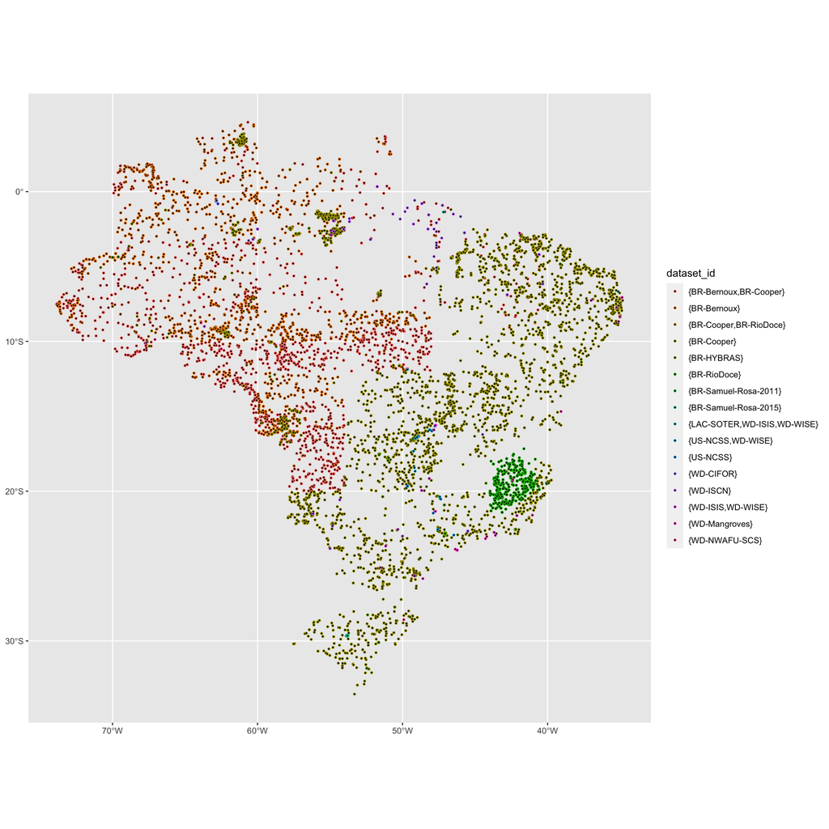

```r
ggplot(data=profiles.gpkg[(profiles.gpkg$country_name=="Brazil"), ]) +
  aes(col=dataset_id) +
  geom_sf(shape=21, size=0.8, fill="black")
```

## 4.2 ESRI shapefiles

### 4.2.1 WoSIS profiles as ESRI Shapefiles

WoSIS WFS is available as ESRI point shapefiles, using `f="ESRI Shapefile"` argument to `ogr2ogr`.

Download the profile information for the whole world. This is a very large file.

```r
layer.name <- "ms_wosis_latest_profiles"
(dst.target.name <- paste0(wosis.dir.name,"/", layer.name, ".shp"))
```

```
## [1] "./wosis_latest/ms_wosis_latest_profiles.shp"
```

```r
if (!file.exists(dst.target.name)) {
system.time(
  gdalUtilities::ogr2ogr(src=wfs,
          dst=wosis.dir.name,
          layer=layer.name,
          f = "ESRI Shapefile",
          overwrite=TRUE,
          skipfailures=TRUE)
)
}
file.info(dst.target.name)$size/1024/1024
```

```
## [1] 5.799534
```

The number of profiles can be restricted with a `spat` spatial extent or a `where` SQL query. For example, to download just the Indian profiles, into a subdirectory:

```r
wosis.dir.name.india <- "./wosis_latest/india"
if (!file.exists(wosis.dir.name.india)) dir.create(wosis.dir.name.india)
layer.name <- "ms_wosis_latest_profiles"
(dst.target.name <- paste0(wosis.dir.name,"/", layer.name, ".shp"))
```

```
## [1] "./wosis_latest/ms_wosis_latest_profiles.shp"
```

```r
if (!file.exists(dst.target.name)) {
  system.time(
  gdalUtilities::ogr2ogr(src=wfs,
          dst=wosis.dir.name.india,
          layer=layer.name,
          f = "ESRI Shapefile",
          where="country_name='India'",
          overwrite=TRUE,
          skipfailures=TRUE)
)
}
file.info(dst.target.name)$size/1024/1024
```

```
## [1] 5.799534
```

### 4.2.2 Reading imported profiles into R

```r
layer.name <- "ms_wosis_latest_profiles"
profiles <- sf::st_read(dsn=wosis.dir.name, layer=layer.name,
                stringsAsFactors = FALSE)
class(profiles)
```

```
## [1] "sf"         "data.frame"
```

```r
dim(profiles)
```

```
## [1] 217184     76
```

```r
names(profiles)
```

```
##  [1] "gml_id"     "profile_id" "dataset_id" "continent"  "country_id"
##  [6] "country_na" "geom_accur" "latitude"   "longitude"  "dsds"
## [11] "cfao_versi" "cfao_major" "cfao_maj_1" "cfao_soil_" "cfao_soi_1"
## [16] "cwrb_versi" "cwrb_refer" "cwrb_ref_1" "cwrb_prefi" "cwrb_suffi"
## [21] "cstx_versi" "cstx_order" "cstx_subor" "cstx_great" "cstx_subgr"
## [26] "bdfi33"     "bdfiad"     "bdfifm"     "bdfiod"     "bdws33"
## [31] "bdwsad"     "bdwsfm"     "bdwsod"     "cecph7"     "cecph8"
## [36] "cfgr"       "cfvo"       "clay"       "ecec"       "elco20"
## [41] "elco25"     "elco50"     "elcosp"     "nitkjd"     "orgc"
## [46] "orgm"       "phaq"       "phba"       "phca"       "phetb1"
## [51] "phetm3"     "phetol"     "phkc"       "phnf"       "phprtn"
## [56] "phptot"     "phpwsl"     "sand"       "silt"       "tceq"
## [61] "totc"       "wg0006"     "wg0010"     "wg0033"     "wg0100"
## [66] "wg0200"     "wg0500"     "wg1500"     "wv0006"     "wv0010"
## [71] "wv0033"     "wv0100"     "wv0200"     "wv0500"     "wv1500"
## [76] "geometry"
```

```r
head(profiles)
```

```
## Simple feature collection with 6 features and 75 fields
## Geometry type: POINT
## Dimension:     XY
## Bounding box:  xmin: -6.4167 ymin: 6.5875 xmax: 2.1525 ymax: 58.3333
## Geodetic CRS:  WGS 84
##                         gml_id profile_id                dataset_id continent
## 1 wosis_latest_profiles.598717     598717                {EU-SPADE}    Europe
## 2 wosis_latest_profiles.598723     598723                {EU-SPADE}    Europe
## 3 wosis_latest_profiles.598856     598856                {EU-SPADE}    Europe
## 4 wosis_latest_profiles.598916     598916                {EU-SPADE}    Europe
## 5 wosis_latest_profiles.598976     598976                {EU-SPADE}    Europe
## 6  wosis_latest_profiles.47431      47431 {AF-AfSP,BJSOTER,WD-WISE}    Africa
##   country_id     country_na geom_accur latitude longitude dsds cfao_versi
## 1         GB United Kingdom      1e-06  58.1333   -4.5667   95       1997
## 2         GB United Kingdom      1e-06  57.2167   -5.8000  100       1997
```

[output cut: 53 more lines]

The Indian profiles:

```r
profiles.india <- sf::st_read(dsn=wosis.dir.name.india, layer=layer.name,
                stringsAsFactors = FALSE)
dim(profiles.india)
```

```
## [1] 199  76
```

```r
names(profiles.india)
```

```
##  [1] "gml_id"     "profile_id" "dataset_id" "continent"  "country_id"
##  [6] "country_na" "geom_accur" "latitude"   "longitude"  "dsds"
## [11] "cfao_versi" "cfao_major" "cfao_maj_1" "cfao_soil_" "cfao_soi_1"
## [16] "cwrb_versi" "cwrb_refer" "cwrb_ref_1" "cwrb_prefi" "cwrb_suffi"
## [21] "cstx_versi" "cstx_order" "cstx_subor" "cstx_great" "cstx_subgr"
## [26] "bdfi33"     "bdfiad"     "bdfifm"     "bdfiod"     "bdws33"
## [31] "bdwsad"     "bdwsfm"     "bdwsod"     "cecph7"     "cecph8"
## [36] "cfgr"       "cfvo"       "clay"       "ecec"       "elco20"
## [41] "elco25"     "elco50"     "elcosp"     "nitkjd"     "orgc"
## [46] "orgm"       "phaq"       "phba"       "phca"       "phetb1"
## [51] "phetm3"     "phetol"     "phkc"       "phnf"       "phprtn"
## [56] "phptot"     "phpwsl"     "sand"       "silt"       "tceq"
## [61] "totc"       "wg0006"     "wg0010"     "wg0033"     "wg0100"
## [66] "wg0200"     "wg0500"     "wg1500"     "wv0006"     "wv0010"
## [71] "wv0033"     "wv0100"     "wv0200"     "wv0500"     "wv1500"
## [76] "geometry"
```

```r
head(profiles.india)
```

```
## Simple feature collection with 6 features and 75 fields
## Geometry type: POINT
## Dimension:     XY
## Bounding box:  xmin: 76.83334 ymin: 10.78333 xmax: 88.95738 ymax: 21.8277
## Geodetic CRS:  WGS 84
##                         gml_id profile_id     dataset_id continent country_id
## 1 wosis_latest_profiles.622261     622261 {WD-Mangroves}      Asia         IN
## 2 wosis_latest_profiles.622883     622883 {WD-Mangroves}      Asia         IN
## 3 wosis_latest_profiles.623762     623762 {WD-NWAFU-SCS}      Asia         IN
## 4 wosis_latest_profiles.622603     622603 {WD-Mangroves}      Asia         IN
## 5 wosis_latest_profiles.622649     622649 {WD-Mangroves}      Asia         IN
## 6 wosis_latest_profiles.623297     623297 {WD-Mangroves}      Asia         IN
##   country_na geom_accur latitude longitude dsds cfao_versi cfao_major
## 1      India      1e-06 20.38793  86.77038   30         NA       <NA>
## 2      India      1e-06 20.39427  86.73617   30         NA       <NA>
```

[output cut: 53 more lines]

### 4.2.3 WoSIS layers as ESRI Shapefiles

Download all records for a single property, here, bulk density, and save it a subdirectory of the current path, and with the default format. The directory must be first created if does not already exist.

Note `f=` argument to specify the format, here ESRI shapefiles.

```r
layer.name <- "ms_wosis_latest_bdfi33"
(dst.target.name <- paste0(wosis.dir.name,"/", layer.name, ".shp"))
```

```
## [1] "./wosis_latest/ms_wosis_latest_bdfi33.shp"
```

```r
if (!file.exists(dst.target.name)) {
  system.time(
  gdalUtilities::ogr2ogr(src=wfs,
          dst=wosis.dir.name,
          layer=layer.name,
          f = "ESRI Shapefile",
          overwrite=TRUE,
          skipfailures=TRUE)
)
}
file.info(dst.target.name)$size/1024/1024
```

```
## [1] 2.084469
```

Because the destination format is `"ESRI Shapefile"` many of the field names have to be shortened, as shown by warnings such as “Warning 6: Normalized/laundered field name: ‘profile_layer_id’ to ‘profile_la’.”

Note that `spat` is not applicable in this query because there is no spatial information in the attribute tables. However, it is possible to include an SQL query with `where` to limit the size of the download:

```r
layer.name <- "ms_wosis_latest_bdfi33"
(dst.target.name <- paste0(wosis.dir.name.india,"/", layer.name, ".shp"))
```

```
## [1] "./wosis_latest/india/ms_wosis_latest_bdfi33.shp"
```

```r
if (!file.exists(dst.target.name)) {
  system.time(
    gdalUtilities::ogr2ogr(src=wfs,
                           dst=wosis.dir.name.india,
                           layer=layer.name,
                           f = "ESRI Shapefile",
                           where="country_name='India'",
                           overwrite=TRUE,
                           skipfailures=TRUE)
  )
}
file.info(dst.target.name)$size/1024/1024
```

```
## [1] 0.003219604
```

### 4.2.4 Reading imported layers into R

Now read the downloaded shapefiles into an R `sf` object.

For shapefiles, the directory and layer names must be specified separately as two arguments, `dsn` (“data set name”) and `layer`. Notice how the server name of this layer which begins with `ms:` has been changed to `ms_` during import, due to restrictions on file names on the local file system.

```r
# here strings are just that, not to be interpreted as R factors
layer.name <- "ms_wosis_latest_bdfi33"
bd33 <- st_read(dsn=wosis.dir.name, layer=layer.name,
                stringsAsFactors = FALSE)
class(bd33)
```

```
## [1] "sf"         "data.frame"
```

```r
names(bd33)
```

```
##  [1] "gml_id"     "profile_id" "profile_la" "country_na" "upper_dept"
##  [6] "lower_dept" "layer_name" "litter"     "bdfi33_val" "bdfi33_v_1"
## [11] "bdfi33_met" "bdfi33_dat" "bdfi33_d_1" "bdfi33_pro" "bdfi33_lic"
## [16] "geometry"
```

```r
head(bd33)
```

```
## Simple feature collection with 6 features and 15 fields
## Geometry type: POINT
## Dimension:     XY
## Bounding box:  xmin: 29.31667 ymin: -3.366667 xmax: 29.31667 ymax: -3.366667
## Geodetic CRS:  WGS 84
##                       gml_id profile_id profile_la country_na upper_dept
## 1 wosis_latest_bdfi33.597709      47145     597709    Burundi          0
## 2 wosis_latest_bdfi33.597710      47145     597710    Burundi         15
## 3 wosis_latest_bdfi33.597711      47145     597711    Burundi         40
## 4 wosis_latest_bdfi33.597712      47145     597712    Burundi         70
## 5 wosis_latest_bdfi33.597713      47145     597713    Burundi        110
## 6 wosis_latest_bdfi33.597714      47145     597714    Burundi        170
##   lower_dept layer_name litter                                  bdfi33_val
## 1         15          A      0 {1:1.41,2:1.41,3:1.08,4:1.08,5:1.12,6:1.12}
## 2         40        Bho      0 {1:1.04,2:1.04,3:0.99,4:0.99,5:1.36,6:1.36}
```

[output cut: 46 more lines]

Each record has some identification:

- `gml_id` the attribute name + `profile_la` (see below)
- `profile_id` profile internal ID
- `profile_la` profile + layer internal ID
- `country_na` country name
- `upper_dept` upper limit of layer from soil surface (excluding litter layer). cm
- `lower_dept` lower limit of layer from soil surface (excluding litter layer), cm
- `layer_name` layer name as assigned during original profile description
- `litter` whether the layer is a litter layer (0 = no, 1 = yes)

Each attribute has several names, with the following extensions:

- `value` – one or more values, in the format {1:value; 2:value…}, which are duplicate measurements
- `value_avg` – the average of the values
- `method` – text description of the analytical method
- `date` – one or more values, in the format {1:yyyy-mm-dd; 2:yyyy-mm-dd…}, which are the dates each of th duplicate measurements was added to the database (not the original measurement date, nor the field sampling date)
- `dataset_id` – text code of original database
- `profile_code` – text code of profile from original database
- `licence` – text string of the Creative Commons[^1] license for this value, e.g. `CC-BY-NC`

So for example the attribute `bdfi33` has the following fields, shortened when input to a shapefile to the first ten characters; if these would be duplicated the name is further manipulated:

- `bdfi33_value` $\to$ `bdfi33_val`
- `bdfi33_value_avg` $\to$ `bdfi33_v_1`
- `bdfi33_method` $\to$ `bdfi33_met`
- `bdfi33_date` $\to$ `bdfi33_dat`
- `bdfi33_dataset_id` $\to$ `bdfi33_d_1`
- `bdfi33_profile_code` $\to$ `bdfi33_pro`
- `bdfi33_licence` $\to$ `bdfi33_lic`

Examine the format of the attribute, this is in field `*_val`:

```r
head(bd33$bdfi33_val)
```

```
## [1] "{1:1.41,2:1.41,3:1.08,4:1.08,5:1.12,6:1.12}"
## [2] "{1:1.04,2:1.04,3:0.99,4:0.99,5:1.36,6:1.36}"
## [3] "{1:1.25,2:1.25,3:0.95,4:0.95,5:0.97,6:0.97}"
## [4] "{1:1.14,2:1.14,3:1.12,4:1.12,5:1.43,6:1.43}"
## [5] "{1:1.42,2:1.42,3:1.12,4:1.12,5:1.14,6:1.14}"
## [6] "{1:1.29,2:1.29,3:1.28,4:1.28,5:1.64,6:1.64}"
```

The format is `{seq:val[,seq:val]}` where the `seq` is an integer on `[1...]` indicating which measurement number – note that there can be more than one measurement per property, e.g., repeated lab. measurements, and `val` is the numeric value.

```r
bd33[75:80, c("profile_id","upper_dept","lower_dept","bdfi33_val","bdfi33_v_1")]
```

```
## Simple feature collection with 6 features and 5 fields
## Geometry type: POINT
## Dimension:     XY
## Bounding box:  xmin: 23.53333 ymin: -19.84944 xmax: 23.53583 ymax: -19.84556
## Geodetic CRS:  WGS 84
##    profile_id upper_dept lower_dept                                  bdfi33_val
## 75      48231        130        160 {1:0.95,2:0.95,3:1.65,4:1.65,5:1.95,6:1.95}
## 76      48234          0         16 {1:0.78,2:0.78,3:1.01,4:1.01,5:0.69,6:0.69}
## 77      48234         16         55 {1:1.45,2:1.45,3:1.83,4:1.83,5:1.67,6:1.67}
## 78      48234         55         94 {1:1.73,2:1.73,3:1.94,4:1.94,5:1.61,6:1.61}
## 79      48234         94        127 {1:1.58,2:1.58,3:1.92,4:1.92,5:1.70,6:1.70}
## 80      48234        127        184 {1:1.70,2:1.70,3:1.92,4:1.92,5:1.61,6:1.61}
##    bdfi33_v_1                   geometry
## 75       1.52 POINT (23.53333 -19.84944)
## 76       0.83 POINT (23.53583 -19.84556)
## 77       1.65 POINT (23.53583 -19.84556)
## 78       1.76 POINT (23.53583 -19.84556)
## 79       1.73 POINT (23.53583 -19.84556)
## 80       1.74 POINT (23.53583 -19.84556)
```

Here is the India example. We make a histogram of the representative values.

```r
layer.name <- "ms_wosis_latest_bdfi33"
bd33.india <- st_read(dsn=wosis.dir.name.india, layer=layer.name,
                stringsAsFactors = FALSE)
class(bd33.india)
```

```
## [1] "sf"         "data.frame"
```

```r
dim(bd33.india)
```

```
## [1] 117  16
```

```r
(profile.id.india <- unique(bd33.india$profile_id))
```

```
##  [1]  66490  66492  67280  67281  67282  67283  67294  67295  67296  67782
## [11] 170991 170992 170993 170994 170995 170996 170997 170998 170999 171000
```

```r
names(bd33.india)
```

```
##  [1] "gml_id"     "profile_id" "profile_la" "country_na" "upper_dept"
##  [6] "lower_dept" "layer_name" "litter"     "bdfi33_val" "bdfi33_v_1"
## [11] "bdfi33_met" "bdfi33_dat" "bdfi33_d_1" "bdfi33_pro" "bdfi33_lic"
## [16] "geometry"
```

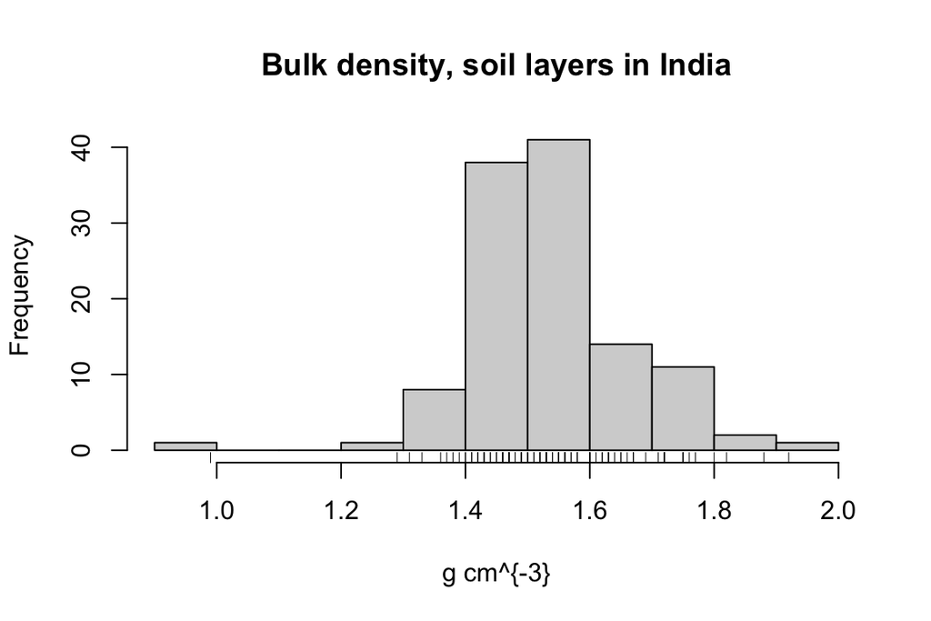

```r
hist(bd33.india$bdfi33_v_1, main="Bulk density, soil layers in India",
     xlab="g cm^{-3}")
rug(bd33.india$bdfi33_v_1)
```

Here there are 117 records in 20 profiles. These profiles can be found in the profiles database.

### 4.2.5 Mapping soil properties

The location of the profiles is given in the `"wosis_latest_profiles"` table, whereas the soil properties are in separate tables, for example `"ms_wosis_latest_bdfi33"` for the bulk density. Both have a `profile_id` field. So to map a property, the profile ID must be used for a left join, to add the coordinates to the properties table.

First, select the bulk densities for a specified depth, here 30 cm:

```r
bd30cm <- bd33.india %>%
  select(profile_id, upper_dept, lower_dept, bdfi33_v_1) %>%
  filter((lower_dept > 30) ) %>%
  group_by(profile_id) %>%    # may be more than one layer deeper than this
  arrange(upper_dept) %>%     # select the shallowest
  filter(row_number() == 1) %>%
  ungroup()
glimpse(bd30cm)
```

```
## Rows: 19
## Columns: 5
## $ profile_id <int> 67782, 67295, 170994, 67281, 66492, 170997, 67280, 170992, …
## $ upper_dept <int> 11, 12, 12, 15, 18, 19, 20, 20, 20, 20, 22, 23, 23, 23, 26,…
## $ lower_dept <int> 38, 38, 38, 36, 46, 55, 42, 39, 39, 34, 43, 42, 34, 36, 48,…
## $ bdfi33_v_1 <dbl> 1.42, 1.72, 1.65, 1.63, 1.45, 1.55, 1.51, 1.64, 1.60, 1.39,…
## $ geometry   <POINT [°]> POINT (75 22.71667), POINT (78 16), POINT (78 16), PO…
```

Now join with the profile information. Note that the geometry information is duplicated, we only need it in the first-named object to be joined.

```r
india.pts <- profiles.india %>%
  select(profile_id, geometry)
bd30cm.j <-
  left_join(india.pts, st_drop_geometry(bd30cm), by="profile_id")
print(bd30cm.j)
```

```
## Simple feature collection with 199 features and 4 fields
## Geometry type: POINT
## Dimension:     XY
## Bounding box:  xmin: 69.8 ymin: 8.483333 xmax: 94.05 ymax: 32
## Geodetic CRS:  WGS 84
## First 10 features:
##    profile_id upper_dept lower_dept bdfi33_v_1                  geometry
## 1      622261         NA         NA         NA POINT (86.77038 20.38793)
## 2      622883         NA         NA         NA POINT (86.73617 20.39427)
## 3      623762         NA         NA         NA POINT (76.83334 10.78333)
## 4      622603         NA         NA         NA POINT (88.33126 21.66687)
## 5      622649         NA         NA         NA POINT (88.95738 21.68509)
## 6      623297         NA         NA         NA  POINT (88.84857 21.8277)
## 7      623769         NA         NA         NA    POINT (80.75 26.66667)
## 8      623283         NA         NA         NA POINT (88.19537 21.70742)
## 9      622421         NA         NA         NA POINT (79.79479 11.43068)
## 10     622650         NA         NA         NA POINT (88.80019 22.09143)
```

Now we can display the map, using the `geom_sf` geometry primitive in `ggplot`. The country boundary is obtained from the `mapdata` package.

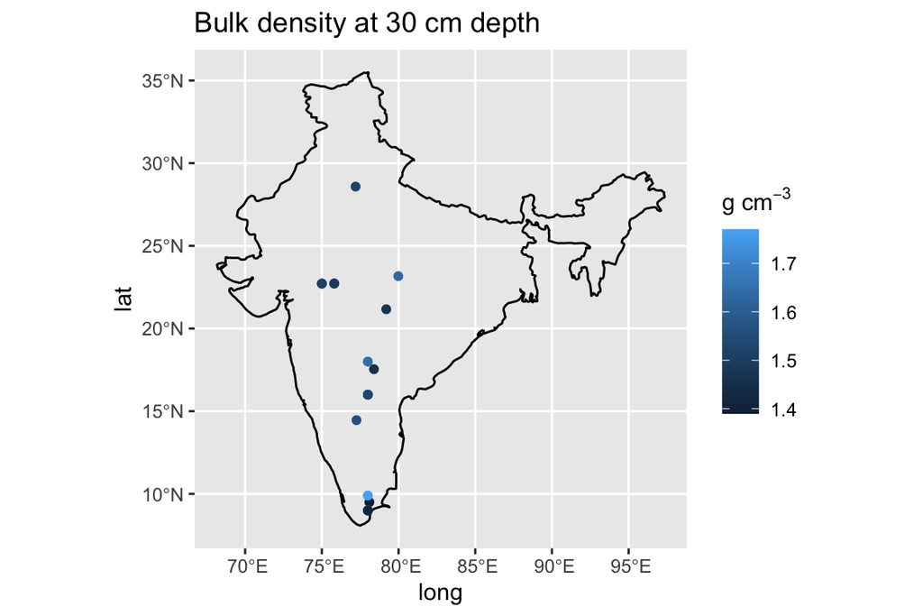

```r
IN <- map_data(map = 'world',
               region = 'India')
# remove named subregions, i.e., the islands
ix <- which(is.na(IN$subregion))
IN <- IN[ix,]
ggplot() +
  geom_path(aes(x = long, y = lat), data=IN) +
  geom_sf(data = bd30cm, aes(col = bdfi33_v_1)) +
  labs(title = "Bulk density at 30 cm depth", col = expression(paste(g," ", cm)^-3))
```

Obviously, there is not much information for this soil property for India.

## 4.3 CSV files

Another output format for `ogr2ogr` is the CSV ‘comma-separated values’ plain-text file. These typically have one header row giving the name of each column (field), and then one row (case, tuple) per observation

### 4.3.1 WoSIS profiles as CSV files

WoSIS WFS is available as CSV files, using `f="CSV"` argument to `ogr2ogr`.

For example, read the profile information for the $2^\circ \times 2^\circ$ tile in central Europe.

```r
wosis.dir.name.ceu <- "./wosis_latest/central_europe"
if (!file.exists(wosis.dir.name.ceu)) dir.create(wosis.dir.name.ceu)
src.layer.name <- "ms:wosis_latest_profiles"
dst.layer.name <- "wosis_latest_profiles_ceu"
(dst.target.name <- paste0(wosis.dir.name.ceu,"/",dst.layer.name,".csv"))
```

```
## [1] "./wosis_latest/central_europe/wosis_latest_profiles_ceu.csv"
```

```r
if (!file.exists(dst.target.name)) {
gdalUtilities::ogr2ogr(src=wfs,
        dst=dst.target.name,
        layer=src.layer.name,
        f="CSV",
        spat=c(6, 48, 8, 50),
        overwrite=TRUE)
}
round(file.info(dst.target.name)$size/1024,1)
```

```
## [1] 73.1
```

This file is about 73 Kb.

### 4.3.2 Read imported CSV-formatted profiles into R

The `read.csv` function reads from a CSV file into an R `data.frame`.

Read the profiles (sites) from central Europe:

```r
layer.name <- "wosis_latest_profiles_ceu"
system.time(
  profiles.ceu <- read.csv(paste0(wosis.dir.name.ceu, "/",layer.name,".csv"),
                stringsAsFactors = FALSE)
)
```

```
##    user  system elapsed
##   0.006   0.000   0.008
```

```r
names(profiles.ceu)
```

```
##  [1] "gml_id"                         "profile_id"
##  [3] "dataset_id"                     "continent"
##  [5] "country_id"                     "country_name"
##  [7] "geom_accuracy"                  "latitude"
##  [9] "longitude"                      "dsds"
## [11] "cfao_version"                   "cfao_major_group_code"
## [13] "cfao_major_group"               "cfao_soil_unit_code"
## [15] "cfao_soil_unit"                 "cwrb_version"
## [17] "cwrb_reference_soil_group_code" "cwrb_reference_soil_group"
## [19] "cwrb_prefix_qualifier"          "cwrb_suffix_qualifier"
## [21] "cstx_version"                   "cstx_order_name"
## [23] "cstx_suborder"                  "cstx_great_group"
## [25] "cstx_subgroup"                  "bdfi33"
## [27] "bdfiad"                         "bdfifm"
## [29] "bdfiod"                         "bdws33"
```

[output cut: 23 more lines]

### 4.3.3 WoSIS layers as CSV files

Get the the bulk density for the layers in these profiles. Note that this query can not be limited by coordinates, since they are not included in this table. So we get all the layers and then limit to the profiles of interest.

```r
src.layer.name <- "wosis_latest_bdfi33"
dst.layer.name <- "wosis_latest_bdfi33"
(dst.target.name <- paste0(wosis.dir.name,"/",dst.layer.name,".csv"))
```

```
## [1] "./wosis_latest/wosis_latest_bdfi33.csv"
```

```r
if (!file.exists(dst.target.name)) {
gdalUtilities::ogr2ogr(src=wfs,
        dst=dst.target.name,
        layer=src.layer.name,
        f="CSV",
        overwrite=TRUE)
}
file.info(dst.target.name)$size/1024/1024
```

```
## [1] 29.34167
```

This is a very large file, about 29 Mb.

### 4.3.4 Read imported layers into R

The bulk density per-layer.

```r
layer.name <- "wosis_latest_bdfi33"
system.time(
  bd33.pts <- read.csv(file=paste0(wosis.dir.name,"/",layer.name,".csv"),
                stringsAsFactors = FALSE)
)
```

```
##    user  system elapsed
##   0.493   0.023   0.517
```

```r
dim(bd33.pts)
```

```
## [1] 21599    15
```

```r
names(bd33.pts)
```

```
##  [1] "gml_id"              "profile_id"          "profile_layer_id"
##  [4] "country_name"        "upper_depth"         "lower_depth"
##  [7] "layer_name"          "litter"              "bdfi33_value"
## [10] "bdfi33_value_avg"    "bdfi33_method"       "bdfi33_date"
## [13] "bdfi33_dataset_id"   "bdfi33_profile_code" "bdfi33_licence"
```

Notice that here we have the complete field names, not truncated as they were in the shapefiles. These can now be processed as above, i.e., the shapefiles.

# 5 Spatial objects

Once the WoSIS profiles have been imported to R they can be converted to a spatial object in the `sf` package, by specifying the coördinates and the Coordinate Reference System (CRS), which we know from the WoSIS metadata is EPSG code 4326 (geographic coordinates on the WGS84 datum).

For example, here are the central Europe profiles as a spatial object:

```r
profiles.ceu <- st_as_sf(profiles.ceu,
                         coords = c("longitude", "latitude"),
                         crs = 4326)
class(profiles.ceu)
```

```
## [1] "sf"         "data.frame"
```

Review some site information, e.g., the WRB Reference Soil Groups:

```r
table(profiles.ceu$cwrb_reference_soil_group)
```

```
##
##             Albeluvisol     Andosol    Cambisol    Fluvisol     Gleysol
##         169           2           2          14           2           4
##    Histosol     Luvisol    Phaeozem      Podzol     Regosol    Umbrisol
##           2          10           2          12           2           2
##    Vertisol
##           1
```

Note that most of these profiles do not have a WRB classification.

Display a map of the profiles with their classification:

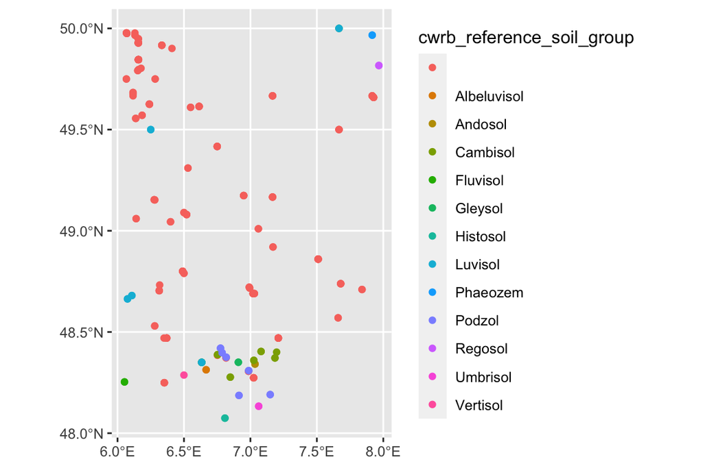

```r
ggplot(data=profiles.ceu) +
  aes(col=cwrb_reference_soil_group) +
  geom_sf()
```

# 6 Working with WoSIS as a `SoilProfileCollection`

The `aqp` “Algorithms for Quantitive Pedology” package (Beaudette, Roudier, and O’Geen 2013) defines data structures and functions specific to soil profile data, i.e., with site and linked layer information.

Load the package, and the `data.table` package on which it depends:

```r
require(data.table)
require(aqp)            # Algorithms for Quantitative Pedology
```

Convert the bulk density `sf` object to a `SoilProfileCollection`, a data type defined in `aqp`. This data type has separate structures for the site (profile) and horizons. It does not have geometry, so we use `st_drop_geometry` to convert the `sf` object to a data frame.

The `aqp::depths` function initializes the SoilProfileCollection object. The formula has the field name of the profile on the left, and the the field names of the horizon boundaries on the right. These fields are in the WoSIS layer.

```r
ds.aqp <- st_drop_geometry(bd33)
depths(ds.aqp) <- profile_id ~ upper_dept + lower_dept
```

```
## converting profile IDs from integer to character
```

```r
is(ds.aqp)
```

```
## [1] "SoilProfileCollection"
```

```r
slotNames(ds.aqp)
```

```
## [1] "idcol"        "hzidcol"      "depthcols"    "metadata"     "horizons"
## [6] "site"         "sp"           "diagnostic"   "restrictions"
```

```r
str(ds.aqp@site)
```

```
## 'data.frame':    12888 obs. of  1 variable:
##  $ profile_id: chr  "135643" "135648" "135653" "135658" ...
```

```r
str(ds.aqp@horizons)
```

```
## 'data.frame':    78058 obs. of  16 variables:
##  $ gml_id    : chr  "wosis_latest_bdfi33.605251" "wosis_latest_bdfi33.605252" "wosis_latest_bdfi33.605253" "wosis_latest_bdfi33.605254" ...
##  $ profile_id: chr  "135643" "135643" "135643" "135643" ...
##  $ profile_la: int  605251 605252 605253 605254 605255 605256 605262 605263 605264 605265 ...
##  $ country_na: chr  "United States of America" "United States of America" "United States of America" "United States of America" ...
##  $ upper_dept: int  5 12 27 64 86 111 6 13 29 46 ...
##  $ lower_dept: int  12 27 64 86 111 157 13 29 46 77 ...
##  $ layer_name: chr  "BA" "Bw1" "Bw2" "2Cd1" ...
##  $ litter    : int  0 0 0 0 0 0 0 0 0 0 ...
##  $ bdfi33_val: chr  "{1:1.65,2:1.65,3:1.34,4:1.34,5:1.39,6:1.39}" "{1:1.46,2:1.46,3:1.72,4:1.72,5:1.44,6:1.44}" "{1:1.47,2:1.47,3:1.49,4:1.49,5:1.73,6:1.73}" "{1:1.91,2:1.91,3:1.68,4:1.68,5:1.71,6:1.71}" ...
##  $ bdfi33_v_1: num  1.46 1.54 1.56 1.77 1.88 1.82 1.24 1.53 1.64 1.7 ...
##  $ bdfi33_met: chr  "{\"1:calculation = not specified, corrections = not specified, measurement condition = equilibrated at 33 kPa ("| __truncated__ "{\"1:calculation = not specified, corrections = not specified, measurement condition = equilibrated at 33 kPa ("| __truncated__ "{\"1:calculation =…
##  $ bdfi33_dat: chr  "{1:1999-7-7,2:1999-7-7,3:1999-7-7,4:1999-7-7,5:1999-7-7,6:1999-7-7}" "{1:1999-7-7,2:1999-7-7,3:1999-7-7,4:1999-7-7,5:1999-7-7,6:1999-7-7}" "{1:1999-7-7,2:1999-7-7,3:1999-7-7,4:1999-7-7,5:1999-7-7,6:1999-7-7}" "{1:1999-7-7,2:1999-7-7,3:1999-7-7,4:1999-7-7,5:1999-7-7,6:1999-7-7…
##  $ bdfi33_d_1: chr  "US-NCSS" "US-NCSS" "US-NCSS" "US-NCSS" ...
##  $ bdfi33_pro: chr  "00P0001" "00P0001" "00P0001" "00P0001" ...
##  $ bdfi33_lic: chr  "U.S. Public Domain http://www.usa.gov/publicdomain/label/1.0/" "U.S. Public Domain http://www.usa.gov/publicdomain/label/1.0/" "U.S. Public Domain http://www.usa.gov/publicdomain/label/1.0/" "U.S. Public Domain http://www.usa.gov/publicdomain/label/1.0/" ...
##  $ hzID      : chr  "1" "2" "3" "4" ...
```

```r
head(ds.aqp@site)
```

```
##   profile_id
## 1     135643
## 2     135648
## 3     135653
## 4     135658
## 5     135663
## 6     135680
```

```r
head(ds.aqp@horizons[c(2,5,6,7,9)],12)
```

```
##    profile_id upper_dept lower_dept layer_name
## 1      135643          5         12         BA
## 2      135643         12         27        Bw1
## 3      135643         27         64        Bw2
## 4      135643         64         86       2Cd1
## 5      135643         86        111       2Cd2
## 6      135643        111        157       2Cd3
## 7      135648          6         13         BA
## 8      135648         13         29        Bw1
## 9      135648         29         46        Bw2
## 10     135648         46         77        Bw3
## 11     135648         77        102        Bw4
## 12     135653          7         21         Bw
##                                     bdfi33_val
## 1  {1:1.65,2:1.65,3:1.34,4:1.34,5:1.39,6:1.39}
## 2  {1:1.46,2:1.46,3:1.72,4:1.72,5:1.44,6:1.44}
## 3  {1:1.47,2:1.47,3:1.49,4:1.49,5:1.73,6:1.73}
## 4  {1:1.91,2:1.91,3:1.68,4:1.68,5:1.71,6:1.71}
## 5  {1:1.83,2:1.83,3:2.01,4:2.01,5:1.81,6:1.81}
## 6  {1:1.74,2:1.74,3:1.76,4:1.76,5:1.97,6:1.97}
## 7  {1:1.39,2:1.39,3:1.14,4:1.14,5:1.18,6:1.18}
## 8  {1:1.47,2:1.47,3:1.69,4:1.69,5:1.44,6:1.44}
## 9  {1:1.56,2:1.56,3:1.58,4:1.58,5:1.78,6:1.78}
## 10 {1:1.83,2:1.83,3:1.62,4:1.62,5:1.64,6:1.64}
## 11 {1:1.59,2:1.59,3:1.78,4:1.78,5:1.58,6:1.58}
## 12 {1:1.10,2:1.10,3:1.12,4:1.12,5:1.33,6:1.33}
```

Note how the horizons have been grouped into sites, in the `@site` slot, and the per-horizon (by depth) values are in the `@horizons` slot. Here we have 78058 horizons in 12888 profiles.

Now this `SoilProfileCollection` can be used for many `aqp` functions. For example, here is the depth distribution of average bulk density of the components for the first 24 listed profiles, labelled by genetic horizon:

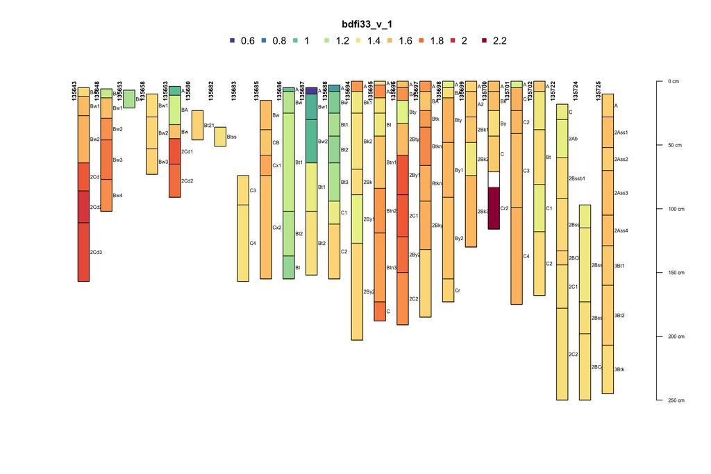

```r
plotSPC(ds.aqp[1:24,], name="layer_name", color='bdfi33_v_1')
```

Several layers in this set of profiles are missing bulk density.

# References

Beaudette, D. E., P. Roudier, and A. T. O’Geen. 2013. “Algorithms for Quantitative Pedology: A Toolkit for Soil Scientists.” *Computers & Geosciences* 52 (March): 258–68. https://doi.org/10.1016/j.cageo.2012.10.020.

[^1]: https://creativecommons.org/licenses/